# Elsevier 2022 SDG mapping

)

)

OR

(

TITLE-ABS

(

"li-s battery"

)

OR TITLE-ABS

(

"li-s batteries"

)

)

OR

(

AUTHKEY

(

"li-s battery"

)

OR AUTHKEY

(

"li-s batteries"

)

)

)

)

OR

(

(

(

TITLE-ABS

(

"investment"

)

AND TITLE-ABS

(

"renewable energy"

)

)

OR

(

AUTHKEY

(

"investment"

)

AND AUTHKEY

(

"renewable energy"

)

)

OR TITLE-ABS

(

"hvdc* cable*"

)

OR AUTHKEY

(

"hvdc* cable*"

)

OR

(

TITLE-ABS

(

"investment* "

)

AND TITLE-ABS

(

"energy"

)

AND TITLE-ABS

(

"GDP"

)

)

OR

(

AUTHKEY

(

"investment* "

)

AND AUTHKEY

(

"energy"

)

AND AUTHKEY

(

"GDP"

)

)

OR

(

TITLE-ABS

(

"international"

)

AND TITLE-ABS

(

"cooperation"

)

AND TITLE-ABS

(

"sustainable energy"

)

)

OR

(

AUTHKEY

(

"international"

)

AND AUTHKEY

(

"cooperation"

)

AND AUTHKEY

(

"sustainable energy"

)

)

OR

(

TITLE-ABS

(

"supply"

)

AND TITLE-ABS

(

"modern electricity"

)

)

OR

(

AUTHKEY

(

"supply"

)

AND AUTHKEY

(

"modern electricity"

)

)

OR

(

TITLE-ABS

(

"supply"

)

AND TITLE-ABS

(

"modern energy"

)

)

OR

(

AUTHKEY

(

"supply"

)

AND AUTHKEY

(

"modern energy"

)

)

OR

(

TITLE-ABS

(

"access"

)

AND TITLE-ABS

(

"affordable energy"

)

)

OR

(

AUTHKEY

(

"access"

)

AND AUTHKEY

(

"affordable energy"

)

)

OR TITLE-ABS

(

"rural energy"

)

OR AUTHKEY

(

"rural energy"

)

OR

(

(

TITLE-ABS("modern energy") OR TITLE-ABS("modern electricity")

)

AND

(

TITLE-ABS("develop* countr*") OR TITLE-ABS("small* island*")

)

)

OR

(

(

AUTHKEY("modern energy") OR AUTHKEY("modern electricity")

)

AND

(

AUTHKEY("develop* countr*") OR AUTHKEY("small* island*")

)

)

OR

(

TITLE-ABS

(

"investment* "

)

AND TITLE-ABS

(

"modern energy"

)

)

OR

(

AUTHKEY

(

"investment* "

)

AND AUTHKEY

(

"modern energy"

)

)

OR

(

TITLE-ABS

(

"international"

)

AND TITLE-ABS

(

" cooperation"

)

AND TITLE-ABS

(

"renewable energy"

)

)

OR

(

AUTHKEY

(

"international"

)

AND AUTHKEY

(

" cooperation"

)

AND AUTHKEY

(

"renewable energy"

)

)

OR

(

TITLE-ABS

(

"Economic cooperation"

)

AND TITLE-ABS

(

"modern energy"

)

)

OR

(

AUTHKEY

(

"Economic cooperation"

)

AND AUTHKEY

(

"modern energy"

)

)

OR

(

(

TITLE-ABS("knowledge transfer") OR TITLE-ABS("technology transfer")

)

AND TITLE-ABS

(

"clean* fuel*"

)

)

OR

(

(

AUTHKEY("knowledge transfer") OR AUTHKEY("technology transfer")

)

AND AUTHKEY

(

"clean* fuel*"

)

)

OR TITLE-ABS

(

"electricity access"

)

OR AUTHKEY

(

"electricity access"

)

OR TITLE-ABS

(

"energy access"

)

OR AUTHKEY

(

"energy access"

)

OR

(

(

TITLE-ABS("knowledge transfer") OR TITLE-ABS("technology transfer")

)

AND TITLE-ABS

(

"clean energy"

)

)

OR

(

(

AUTHKEY("knowledge transfer") OR AUTHKEY("technology transfer")

)

AND AUTHKEY

(

"clean energy"

)

)

OR

(

TITLE-ABS

(

"rural"

)

AND TITLE-ABS

(

"electrification"

)

)

OR

(

AUTHKEY

(

"rural"

)

AND AUTHKEY

(

"electrification"

)

)

OR TITLE-ABS

(

"grid of the future"

)

OR AUTHKEY

(

"grid of the future"

)

OR

(

TITLE-ABS

(

"universal access"

)

AND TITLE-ABS

(

"electricity"

)

)

OR

(

AUTHKEY

(

"universal access"

)

AND AUTHKEY

(

"electricity"

)

)

OR

(

TITLE-ABS

(

"investment*"

)

AND TITLE-ABS

(

"clean energy"

)

)

OR

(

AUTHKEY

(

"investment*"

)

AND AUTHKEY

(

"clean energy"

)

)

OR

(

TITLE-ABS

(

"electricity supply"

)

AND

(

TITLE-ABS("modern") OR TITLE-ABS("clean") OR TITLE-ABS("green") OR TITLE-ABS("sustainable") OR TITLE-ABS("affordable") OR TITLE-ABS("low cost") OR TITLE-ABS("energy efficient") OR TITLE-ABS("renewable") OR TITLE-ABS("hydro*") OR TITLE-ABS("solar") OR TITLE-ABS("wind") OR TITLE-ABS("geothermal")

)

)

OR

(

AUTHKEY

(

"electricity supply"

)

AND

(

AUTHKEY("modern") OR AUTHKEY("clean") OR AUTHKEY("green") OR AUTHKEY("sustainable") OR AUTHKEY("affordable") OR AUTHKEY("low cost") OR AUTHKEY("energy efficient") OR AUTHKEY("renewable") OR AUTHKEY("hydro*") OR AUTHKEY("solar") OR AUTHKEY("wind") OR AUTHKEY("geothermal")

)

)

OR

(

TITLE-ABS

(

"international cooperation"

)

AND TITLE-ABS

(

"clean energy"

)

)

OR

(

AUTHKEY

(

"international cooperation"

)

AND AUTHKEY

(

"clean energy"

)

)

OR

(

TITLE-ABS

(

"investment "

)

AND TITLE-ABS

(

"modern energy"

)

)

OR

(

AUTHKEY

(

"investment "

)

AND AUTHKEY

(

"modern energy"

)

)

OR

(

TITLE-ABS

(

"international"

)

AND TITLE-ABS

(

"cooperation"

)

AND TITLE-ABS

(

"clean* fuel*"

)

)

OR

(

AUTHKEY

(

"international"

)

AND AUTHKEY

(

"cooperation"

)

AND AUTHKEY

(

"clean* fuel*"

)

)

OR

(

TITLE-ABS

(

"access"

)

AND TITLE-ABS

(

"reliable energy"

)

)

OR

(

AUTHKEY

(

"access"

)

AND AUTHKEY

(

"reliable energy"

)

)

OR TITLE-ABS

(

"hvdc* system*"

)

OR AUTHKEY

(

"hvdc* system*"

)

OR

(

(

TITLE-ABS("knowledge transfer") OR TITLE-ABS("technology transfer")

)

AND TITLE-ABS

(

"renewable energy"

)

)

OR

(

(

AUTHKEY("knowledge transfer") OR AUTHKEY("technology transfer")

)

AND AUTHKEY

(

"renewable energy"

)

)

OR TITLE-ABS

(

"rural energy"

)

OR AUTHKEY

(

"rural energy"

)

OR

(

TITLE-ABS

(

"international"

)

AND TITLE-ABS

(

" cooperation"

)

AND TITLE-ABS

(

"clean energy"

)

)

OR

(

AUTHKEY

(

"international"

)

AND AUTHKEY

(

" cooperation"

)

AND AUTHKEY

(

"clean energy"

)

)

OR

(

TITLE-ABS

(

"access"

)

AND TITLE-ABS

(

"sustainable energy"

)

)

OR

(

AUTHKEY

(

"access"

)

AND AUTHKEY

(

"sustainable energy"

)

)

OR TITLE-ABS

(

"hvdc* line*"

)

OR AUTHKEY

(

"hvdc* line*"

)

OR

(

TITLE-ABS

(

"supply"

)

AND TITLE-ABS

(

"renewable energy"

)

)

OR

(

AUTHKEY

(

"supply"

)

AND AUTHKEY

(

"renewable energy"

)

)

OR

(

TITLE-ABS

(

"access"

)

AND TITLE-ABS

(

"renewable energy"

)

)

OR

(

AUTHKEY

(

"access"

)

AND AUTHKEY

(

"renewable energy"

)

)

OR

(

TITLE-ABS

(

"Economic cooperation"

)

AND TITLE-ABS

(

"renewable energy"

)

)

OR

(

AUTHKEY

(

"Economic cooperation"

)

AND AUTHKEY

(

"renewable energy"

)

)

OR

(

(

TITLE-ABS("access") AND TITLE-ABS("low-cost electricity")

)

OR

(

TITLE-ABS("access") AND TITLE-ABS("lowcost electricity")

)

)

OR

(

(

AUTHKEY("access") AND AUTHKEY("low-cost electricity")

)

OR

(

AUTHKEY("access") AND AUTHKEY("lowcost electricity")

)

)

OR TITLE-ABS

(

"hvdc transmission"

)

OR AUTHKEY

(

"hvdc transmission"

)

OR

(

TITLE-ABS

(

"access"

)

AND TITLE-ABS

(

"modern electricity"

)

)

OR

(

AUTHKEY

(

"access"

)

AND AUTHKEY

(

"modern electricity"

)

)

OR

(

TITLE-ABS

(

"poor"

)

AND TITLE-ABS

(

"electrification"

)

AND

(

TITLE-ABS("neighborhood*") OR TITLE-ABS("hous*") OR TITLE-ABS("district") OR TITLE-ABS("urban") OR TITLE-ABS("the poor") OR TITLE-ABS("customer*")

)

)

OR

(

AUTHKEY

(

"poor"

)

AND AUTHKEY

(

"electrification"

)

AND

(

AUTHKEY("neighborhood*") OR AUTHKEY("hous*") OR AUTHKEY("district") OR AUTHKEY("urban") OR AUTHKEY("the poor") OR AUTHKEY("customer*")

)

)

OR TITLE-ABS

(

"peak load shifting"

)

OR AUTHKEY

(

"peak load shifting"

)

OR

(

TITLE-ABS

(

"access"

)

AND TITLE-ABS

(

"affordable electricity"

)

)

OR

(

AUTHKEY

(

"access"

)

AND AUTHKEY

(

"affordable electricity"

)

)

OR

(

TITLE-ABS

(

"investment* "

)

AND TITLE-ABS

(

"energy"

)

AND TITLE-ABS

(

"GDP"

)

)

OR

(

AUTHKEY

(

"investment* "

)

AND AUTHKEY

(

"energy"

)

AND AUTHKEY

(

"GDP"

)

)

OR TITLE-ABS

(

"rural electricity"

)

OR AUTHKEY

(

"rural electricity"

)

OR TITLE-ABS

(

"hvdc* network*"

)

OR AUTHKEY

(

"hvdc* network*"

)

OR

(

TITLE-ABS

(

"supply"

)

AND TITLE-ABS

(

"renewable electricity"

)

)

OR

(

AUTHKEY

(

"supply"

)

AND AUTHKEY

(

"renewable electricity"

)

)

OR

(

TITLE-ABS

(

"Economic cooperation"

)

AND TITLE-ABS

(

"sustainable energy"

)

)

OR

(

AUTHKEY

(

"Economic cooperation"

)

AND AUTHKEY

(

"sustainable energy"

)

)

OR

(

TITLE-ABS

(

"access"

)

AND TITLE-ABS

(

"modern energy"

)

)

OR

(

AUTHKEY

(

"access"

)

AND AUTHKEY

(

"modern energy"

)

)

OR

(

(

TITLE-ABS("supply") AND TITLE-ABS("low-cost electricity")

)

OR

(

TITLE-ABS("supply") AND TITLE-ABS("lowcost electricity")

)

)

OR

(

(

AUTHKEY("supply") AND AUTHKEY("low-cost electricity")

)

OR

(

AUTHKEY("supply") AND AUTHKEY("lowcost electricity")

)

)

OR TITLE-ABS

(

"hvdc power transmission"

)

OR AUTHKEY

(

"hvdc power transmission"

)

OR

(

(

TITLE-ABS("knowledge transfer") OR TITLE-ABS("technology transfer")

)

AND TITLE-ABS

(

"modern energy"

)

)

OR

(

(

AUTHKEY("knowledge transfer") OR AUTHKEY("technology transfer")

)

AND AUTHKEY

(

"modern energy"

)

)

OR

(

TITLE-ABS

(

"international cooperation"

)

AND TITLE-ABS

(

"energy* efficien*"

)

)

OR

(

AUTHKEY

(

"international cooperation"

)

AND AUTHKEY

(

"energy* efficien*"

)

)

OR TITLE-ABS

(

"access to electricity"

)

OR AUTHKEY

(

"access to electricity"

)

OR

(

TITLE-ABS

(

"supply"

)

AND TITLE-ABS

(

"reliable energy"

)

)

OR

(

AUTHKEY

(

"supply"

)

AND AUTHKEY

(

"reliable energy"

)

)

OR

(

TITLE-ABS

(

"investment"

)

AND TITLE-ABS

(

"clean energy"

)

)

OR

(

AUTHKEY

(

"investment"

)

AND AUTHKEY

(

"clean energy"

)

)

OR

(

TITLE-ABS

(

"access"

)

AND TITLE-ABS

(

"clean electricity"

)

)

OR

(

AUTHKEY

(

"access"

)

AND AUTHKEY

(

"clean electricity"

)

)

OR

(

TITLE-ABS

(

"Economic cooperation"

)

AND TITLE-ABS

(

"sustainable energy"

)

)

OR

(

AUTHKEY

(

"Economic cooperation"

)

AND AUTHKEY

(

"sustainable energy"

)

)

OR

(

TITLE-ABS

(

"high-voltage direct current"

)

OR TITLE-ABS

(

"highvoltage direct current"

)

)

OR

(

AUTHKEY

(

"high-voltage direct current"

)

OR AUTHKEY

(

"highvoltage direct current"

)

)

OR

(

(

TITLE-ABS("sustainable energy") OR TITLE-ABS("sustainable electricity")

)

AND

(

TITLE-ABS("develop* countr*") OR TITLE-ABS("small* island*")

)

)

OR

(

(

AUTHKEY("sustainable energy") OR AUTHKEY("sustainable electricity")

)

AND

(

AUTHKEY("develop* countr*") OR AUTHKEY("small* island*")

)

)

OR

(

TITLE-ABS

(

"develop* countr*"

)

AND TITLE-ABS

(

"electrification"

)

)

OR

(

AUTHKEY

(

"develop* countr*"

)

AND AUTHKEY

(

"electrification"

)

)

OR

(

(

(TITLE-ABS("renewable energy") OR TITLE-ABS("renewable electricity")) AND TITLE-ABS("off-grid")

)

OR

(

(TITLE-ABS("renewable energy") OR TITLE-ABS("renewable electricity")) AND TITLE-ABS("offgrid")

)

)

OR

(

(

(AUTHKEY("renewable energy") OR AUTHKEY("renewable electricity")) AND AUTHKEY("off-grid")

)

OR

(

(AUTHKEY("renewable energy") OR AUTHKEY("renewable electricity")) AND AUTHKEY("offgrid")

)

)

OR TITLE-ABS

(

"hvdc* grid*"

)

OR AUTHKEY

(

"hvdc* grid*"

)

OR

(

(

TITLE-ABS("knowledge transfer") OR TITLE-ABS("technology transfer")

)

AND TITLE-ABS

(

"energy* efficien*"

)

)

OR

(

(

AUTHKEY("knowledge transfer") OR AUTHKEY("technology transfer")

)

AND AUTHKEY

(

"energy* efficien*"

)

)

OR TITLE-ABS

(

"rural energy"

)

OR AUTHKEY

(

"rural energy"

)

OR

(

TITLE-ABS

(

"access"

)

AND TITLE-ABS

(

"sustainable electricity"

)

)

OR

(

AUTHKEY

(

"access"

)

AND AUTHKEY

(

"sustainable electricity"

)

)

OR TITLE-ABS

(

"rural electrification"

)

OR AUTHKEY

(

"rural electrification"

)

OR

(

TITLE-ABS

(

"Economic cooperation"

)

AND TITLE-ABS

(

"clean energy"

)

)

OR

(

AUTHKEY

(

"Economic cooperation"

)

AND AUTHKEY

(

"clean energy"

)

)

OR

(

TITLE-ABS

(

"access"

)

AND TITLE-ABS

(

"clean fuels"

)

)

OR

(

AUTHKEY

(

"access"

)

AND AUTHKEY

(

"clean fuels"

)

)

OR

(

TITLE-ABS

(

"access"

)

AND TITLE-ABS

(

"clean cooking"

)

)

OR

(

AUTHKEY

(

"access"

)

AND AUTHKEY

(

"clean cooking"

)

)

OR

(

TITLE-ABS

(

"supply"

)

AND TITLE-ABS

(

"reliable electricity"

)

)

OR

(

AUTHKEY

(

"supply"

)

AND AUTHKEY

(

"reliable electricity"

)

)

OR

(

TITLE-ABS

(

"electricity"

)

AND TITLE-ABS

(

"access"

)

AND

(

TITLE-ABS("modern") OR TITLE-ABS("clean") OR TITLE-ABS("green") OR TITLE-ABS("sustainable") OR TITLE-ABS("affordable") OR TITLE-ABS("low cost") OR TITLE-ABS("energy efficient") OR TITLE-ABS("renewable") OR TITLE-ABS("hydro*") OR TITLE-ABS("solar") OR TITLE-ABS("wind") OR TITLE-ABS("geothermal")

)

)

OR

(

AUTHKEY

(

"electricity"

)

AND AUTHKEY

(

"access"

)

AND

(

AUTHKEY("modern") OR AUTHKEY("clean") OR AUTHKEY("green") OR AUTHKEY("sustainable") OR AUTHKEY("affordable") OR AUTHKEY("low cost") OR AUTHKEY("energy efficient") OR AUTHKEY("renewable") OR AUTHKEY("hydro*") OR AUTHKEY("solar") OR AUTHKEY("wind") OR AUTHKEY("geothermal")

)

)

OR

(

TITLE-ABS

(

"supply"

)

AND TITLE-ABS

(

"affordable energy"

)

)

OR

(

AUTHKEY

(

"supply"

)

AND AUTHKEY

(

"affordable energy"

)

)

OR

(

TITLE-ABS

(

"high-voltage dc"

)

OR TITLE-ABS

(

"highvoltage dc"

)

)

OR

(

AUTHKEY

(

"high-voltage dc"

)

OR AUTHKEY

(

"highvoltage dc"

)

)

OR

(

TITLE-ABS

(

"access"

)

AND TITLE-ABS

(

"reliable electricity"

)

)

OR

(

AUTHKEY

(

"access"

)

AND AUTHKEY

(

"reliable electricity"

)

)

OR

(

(

(TITLE-ABS("modern energy") OR TITLE-ABS("modern electricity")) AND TITLE-ABS("off-grid")

)

OR

(

(TITLE-ABS("modern energy") OR TITLE-ABS("modern electricity")) AND TITLE-ABS("offgrid")

)

)

OR

(

(

(AUTHKEY("modern energy") OR AUTHKEY("modern electricity")) AND AUTHKEY("off-grid")

)

OR

(

(AUTHKEY("modern energy") OR AUTHKEY("modern electricity")) AND AUTHKEY("offgrid")

)

)

OR

(

TITLE-ABS

(

"access"

)

AND TITLE-ABS

(

"modern cooking"

)

)

OR

(

AUTHKEY

(

"access"

)

AND AUTHKEY

(

"modern cooking"

)

)

OR

(

TITLE-ABS

(

"universal access"

)

AND TITLE-ABS

(

"energy"

)

)

OR

(

AUTHKEY

(

"universal access"

)

AND AUTHKEY

(

"energy"

)

)

OR

(

TITLE-ABS

(

"investment*"

)

AND TITLE-ABS

(

"renewable energy"

)

)

OR

(

AUTHKEY

(

"investment*"

)

AND AUTHKEY

(

"renewable energy"

)

)

OR

(

TITLE-ABS

(

"investment "

)

AND TITLE-ABS

(

"energy"

)

AND TITLE-ABS

(

"GDP"

)

)

OR

(

AUTHKEY

(

"investment "

)

AND AUTHKEY

(

"energy"

)

AND AUTHKEY

(

"GDP"

)

)

OR

(

TITLE-ABS

(

"access"

)

AND TITLE-ABS

(

"clean energy"

)

)

OR

(

AUTHKEY

(

"access"

)

AND AUTHKEY

(

"clean energy"

)

)

OR TITLE-ABS

(

"clean cooking"

)

OR AUTHKEY

(

"clean cooking"

)

OR TITLE-ABS

(

"modern* cooking* fuel*"

)

OR AUTHKEY

(

"modern* cooking* fuel*"

)

OR

(

TITLE-ABS

(

"Economic cooperation"

)

AND TITLE-ABS

(

"energy* efficien*"

)

)

OR

(

AUTHKEY

(

"Economic cooperation"

)

AND AUTHKEY

(

"energy* efficien*"

)

)

OR

(

(

(TITLE-ABS("sustainable energy") OR TITLE-ABS("sustainable electricity")) AND TITLE-ABS("off-grid")

)

OR

(

(TITLE-ABS("sustainable energy") OR TITLE-ABS("sustainable electricity")) AND TITLE-ABS("offgrid")

)

)

OR

(

(

(AUTHKEY("sustainable energy") OR AUTHKEY("sustainable electricity")) AND AUTHKEY("off-grid")

)

OR

(

(AUTHKEY("sustainable energy") OR AUTHKEY("sustainable electricity")) AND AUTHKEY("offgrid")

)

)

OR TITLE-ABS

(

"hvdc* converter*"

)

OR AUTHKEY

(

"hvdc* converter*"

)

OR

(

TITLE-ABS

(

"investment* "

)

AND TITLE-ABS

(

"electricity"

)

AND TITLE-ABS

(

"GDP"

)

)

OR

(

AUTHKEY

(

"investment* "

)

AND AUTHKEY

(

"electricity"

)

AND AUTHKEY

(

"GDP"

)

)

OR

(

TITLE-ABS

(

"international"

)

AND TITLE-ABS

(

" cooperation"

)

AND TITLE-ABS

(

"modern energy"

)

)

OR

(

AUTHKEY

(

"international"

)

AND AUTHKEY

(

" cooperation"

)

AND AUTHKEY

(

"modern energy"

)

)

OR

(

(

((TITLE-ABS("smart grid") OR TITLE-ABS("smart grids") OR TITLE-ABS("smarter grid") OR TITLE-ABS("smarter grids") OR TITLE-ABS("smartgrid") OR TITLE-ABS("smartgrids") OR TITLE-ABS("smart grid tech*") OR TITLE-ABS("smart home*")) AND ((TITLE-ABS("grid") OR TITLE-ABS("power") OR TITLE-ABS("energy")) OR TITLE-ABS("smart building*")) AND ((TITLE-ABS("grid") OR TITLE-ABS("power") OR TITLE-ABS("energy")) OR TITLE-ABS("smart meter*") OR TITLE-ABS("home area network")) AND (TITLE-ABS("grid") OR TITLE-ABS("automation")) AND (TITLE-ABS("power grid") OR TITLE-ABS("manage power consumption") OR TITLE-ABS("distribution intelligence") OR TITLE-ABS("dynamic optimization")) AND (TITLE-ABS("grid") OR TITLE-ABS("self heal*")) AND ((TITLE-ABS("power grid") OR TITLE-ABS("smart grid") OR TITLE-ABS("electric* grid")) OR TITLE-ABS("prosumer")) AND (TITLE-ABS("grid") OR TITLE-ABS("active distribution system") OR TITLE-ABS("active distribution network") OR TITLE-ABS("pev")) AND (TITLE-ABS("grid") OR TITLE-ABS("phev")) AND (TITLE-ABS("grid") OR TITLE-ABS("plug-in electric vehicle*")) AND (TITLE-ABS("grid") OR TITLE-ABS("plug-in hybrid electric vehicle*")) AND (TITLE-ABS("grid") OR TITLE-ABS("ev charging")) AND TITLE-ABS("grid")) AND NOT (((TITLE-ABS("electron") OR TITLE-ABS("electric vehicle charging")) AND (TITLE-ABS("grid") OR TITLE-ABS("vehicle to grid") OR TITLE-ABS("v2g") OR TITLE-ABS("microgrid") OR TITLE-ABS("microgrids") OR TITLE-ABS("microgeneration") OR TITLE-ABS("distributed generat*") OR TITLE-ABS("distributed grid")))) AND NOT (((TITLE-ABS("computing") OR TITLE-ABS("dg unit") OR TITLE-ABS("islanding")) AND (TITLE-ABS("power") OR TITLE-ABS("electric*") OR TITLE-ABS("microgrid*") OR TITLE-ABS("distributed generat*") OR TITLE-ABS("grid-connected") OR TITLE-ABS("detection")) AND TITLE-ABS(--Avoids) AND TITLE-ABS(unrelated) AND TITLE-ABS(materials) AND (TITLE-ABS(articles.) OR TITLE-ABS("anti-islanding") OR TITLE-ABS("controlled islanding") OR TITLE-ABS("zigbee")) AND (TITLE-ABS("grid") OR TITLE-ABS("cybersecurity")) AND (TITLE-ABS("grid") OR TITLE-ABS("home energy management system") OR TITLE-ABS("grid friendly appliance*") OR TITLE-ABS("energy storage system*")) AND (TITLE-ABS("grid") OR TITLE-ABS("data attack*")) AND (TITLE-ABS("grid") OR TITLE-ABS("data injection")) AND (TITLE-ABS("grid") OR TITLE-ABS("advanced meter infrastructure*") OR TITLE-ABS("real-time pricing")) AND (TITLE-ABS("grid") OR TITLE-ABS("reactive power sharing") OR TITLE-ABS("demand response")) AND ((TITLE-ABS("grid") OR TITLE-ABS("electric*") OR TITLE-ABS("power")) OR TITLE-ABS("volt VAR") OR TITLE-ABS("aggregator*")) AND (TITLE-ABS("grid") OR TITLE-ABS("power system automation") OR TITLE-ABS("synchrophasor*") OR TITLE-ABS("Digital fault recorder") OR TITLE-ABS("renewable energy")) AND ((TITLE-ABS("grid integration") OR TITLE-ABS("microgrid")) OR TITLE-ABS("wind")) AND ((TITLE-ABS("grid integration") OR TITLE-ABS("microgrid")) OR TITLE-ABS("solar")) AND ((TITLE-ABS("grid integration") OR TITLE-ABS("microgrid")) OR TITLE-ABS("PV")) AND (TITLE-ABS("grid integration") OR TITLE-ABS("microgrid"))))

)

OR

(

((AUTHKEY("smart grid") OR AUTHKEY("smart grids") OR AUTHKEY("smarter grid") OR AUTHKEY("smarter grids") OR AUTHKEY("smartgrid") OR AUTHKEY("smartgrids") OR AUTHKEY("smart grid tech*") OR AUTHKEY("smart home*")) AND ((AUTHKEY("grid") OR AUTHKEY("power") OR AUTHKEY("energy")) OR AUTHKEY("smart building*")) AND ((AUTHKEY("grid") OR AUTHKEY("power") OR AUTHKEY("energy")) OR AUTHKEY("smart meter*") OR AUTHKEY("home area network")) AND (AUTHKEY("grid") OR AUTHKEY("automation")) AND (AUTHKEY("power grid") OR AUTHKEY("manage power consumption") OR AUTHKEY("distribution intelligence") OR AUTHKEY("dynamic optimization")) AND (AUTHKEY("grid") OR AUTHKEY("self heal*")) AND ((AUTHKEY("power grid") OR AUTHKEY("smart grid") OR AUTHKEY("electric* grid")) OR AUTHKEY("prosumer")) AND (AUTHKEY("grid") OR AUTHKEY("active distribution system") OR AUTHKEY("active distribution network") OR AUTHKEY("pev")) AND (AUTHKEY("grid") OR AUTHKEY("phev")) AND (AUTHKEY("grid") OR AUTHKEY("plug-in electric vehicle*")) AND (AUTHKEY("grid") OR AUTHKEY("plug-in hybrid electric vehicle*")) AND (AUTHKEY("grid") OR AUTHKEY("ev charging")) AND AUTHKEY("grid")) AND NOT (((AUTHKEY("electron") OR AUTHKEY("electric vehicle charging")) AND (AUTHKEY("grid") OR AUTHKEY("vehicle to grid") OR AUTHKEY("v2g") OR AUTHKEY("microgrid") OR AUTHKEY("microgrids") OR AUTHKEY("microgeneration") OR AUTHKEY("distributed generat*") OR AUTHKEY("distributed grid")))) AND NOT (((AUTHKEY("computing") OR AUTHKEY("dg unit") OR AUTHKEY("islanding")) AND (AUTHKEY("power") OR AUTHKEY("electric*") OR AUTHKEY("microgrid*") OR AUTHKEY("distributed generat*") OR AUTHKEY("grid-connected") OR AUTHKEY("detection")) AND AUTHKEY(--Avoids) AND AUTHKEY(unrelated) AND AUTHKEY(materials) AND (AUTHKEY(articles.) OR AUTHKEY("anti-islanding") OR AUTHKEY("controlled islanding") OR AUTHKEY("zigbee")) AND (AUTHKEY("grid") OR AUTHKEY("cybersecurity")) AND (AUTHKEY("grid") OR AUTHKEY("home energy management system") OR AUTHKEY("grid friendly appliance*") OR AUTHKEY("energy storage system*")) AND (AUTHKEY("grid") OR AUTHKEY("data attack*")) AND (AUTHKEY("grid") OR AUTHKEY("data injection")) AND (AUTHKEY("grid") OR AUTHKEY("advanced meter infrastructure*") OR AUTHKEY("real-time pricing")) AND (AUTHKEY("grid") OR AUTHKEY("reactive power sharing") OR AUTHKEY("demand response")) AND ((AUTHKEY("grid") OR AUTHKEY("electric*") OR AUTHKEY("power")) OR AUTHKEY("volt VAR") OR AUTHKEY("aggregator*")) AND (AUTHKEY("grid") OR AUTHKEY("power system automation") OR AUTHKEY("synchrophasor*") OR AUTHKEY("Digital fault recorder") OR AUTHKEY("renewable energy")) AND ((AUTHKEY("grid integration") OR AUTHKEY("microgrid")) OR AUTHKEY("wind")) AND ((AUTHKEY("grid integration") OR AUTHKEY("microgrid")) OR AUTHKEY("solar")) AND ((AUTHKEY("grid integration") OR AUTHKEY("microgrid")) OR AUTHKEY("PV")) AND (AUTHKEY("grid integration") OR AUTHKEY("microgrid"))))

)

)

)

)

## Subfields of science

In this section, we show how the publication set, captured by the query above, relates to the [Science-Metrix classification system](https://science-metrix.com/?q=en/classification)

As shown in figure 1, the publications related to this publication set fall mainly under the subfields of Energy (439,354 publications), Electrical & Electronic Engineering (116,849), and Applied Physics (116,400). Percentages alongside each subfield indicate the total share of each subfield included under the publication set.

Figure 1. Top 25 subfields with the largest percentage of Scopus publications included in the publication set.

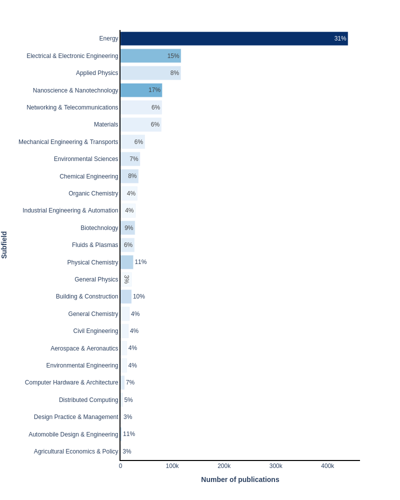

Figure 1. Top 25 subfields with the largest percentage of Scopus publication included in the publication set.

## Journals

In this section, we show how the publication set, captured by the query above, relates to scholarly journals. Journals are sorted in terms of their relevance using term frequency-inverse document frequency (TF-IDF). The horizontal bars are proportional to the number of publications contributed by the journal to the current publication set. The number alongside the horizontal bar is the proportion of the journal contributing to this publication set.

The articles on this topic are published most frequently in the following journals: *International Journal of Hydrogen Energy* (30,698 publications), *Journal of Power Sources* (22,323), and *Energies* (16,299).

Note, larger journals may not appear in the table below, as their SDG contribution may be relatively small compared to the size of the journal.

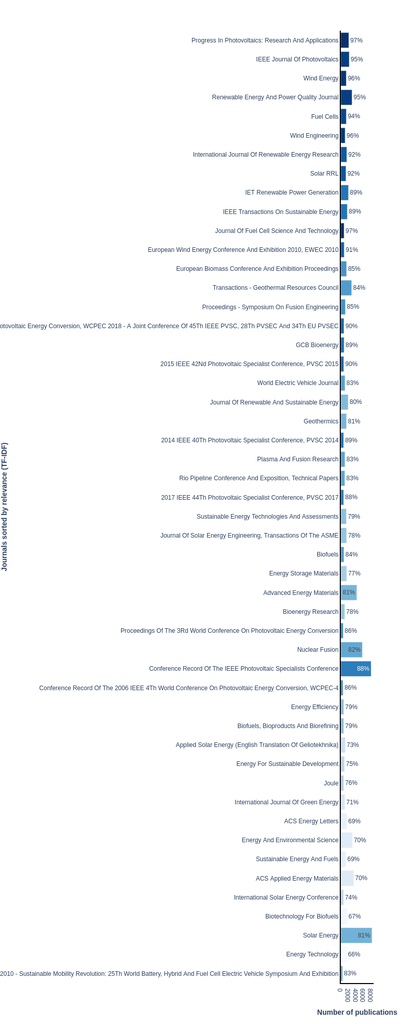

Figure 2. Top 50 journals, in terms of relevance (TF-IDF), for this publication set.

## Keywords

Elsevier’s [Scopus](https://www.scopus.com/search/form.uri?display=basic#basic) database of scientific literature, was used for the table below. The document types included in the data sets are journal articles, reviews, short surveys and conference papers, covering the period 1996–2022. We refer to these documents collectively as “publications” or “papers”.

In order to help better illustrate the content of this set of publications, indicators associated with the keywords most specific to this set (according to a TF-IDF score) are presented below.

|  | Term | # of papers with this term in the publication set | # of papers with this term in all of Scopus | Relevance (TF-IDF) | Percentage of Scopus |
| --- | --- | --- | --- | --- | --- |
| 1 | polymer solar cells (pscs) | 1886 | 1947 | 18.8494 | 97 |
| 2 | bulk heterojunction solar cells | 2070 | 2148 | 18.8435 | 96 |
| 3 | lithium ion batteries (libs) | 2016 | 2099 | 18.8365 | 96 |
| 4 | bulk heterojunction solar cell | 2345 | 2444 | 18.835 | 96 |
| 5 | it-sofc | 1940 | 2041 | 18.8157 | 95 |
| 6 | anode-supported | 1961 | 2071 | 18.809 | 95 |
| 7 | dye-sensitized solar cells. | 2122 | 2246 | 18.8067 | 94 |
| 8 | dye-sensitized solar cells (dscs) | 1383 | 1436 | 18.8029 | 96 |
| 9 | intermediate temperature solid oxide fuel cell | 1550 | 1628 | 18.7994 | 95 |
| 10 | sodium ion batteries | 2700 | 2857 | 18.7984 | 95 |

[output cut: 990 more lines]